# Calibración y Selección de Modelos en Paralelo

## Calibrando el método “Máquinas Vectoriales de Soporte” para los datos de Scoring de Crédito

## Versión NO Paralela

#### Para esto usaremos archivo “MuestraCredito5000V2.csv”"

**En el caso del Scoring de Crédito lo que más interesa en detectar a los NO pagadores, por esa razón ejecutaremos 5 veces la validación cruzada usando 10 grupos. En cada paso de la valización cruzada vamos sumando los no pagadores detectados, luego para cada ejecución de la valizadación cruzada almacenamos la detección de los no pagadores en una entrada del vector respectivo al método para luego hacer un gráfico comparativo.**

```r
setwd("~/Desktop/Datos/")
datos <- read.csv("MuestraCredito5000V2.csv", sep = ";", header=T)

# Recodifica las variables como categóricas ordinales
datos$IngresoNeto <- factor(datos$IngresoNeto,ordered = TRUE)
datos$CoefCreditoAvaluo <- factor(datos$CoefCreditoAvaluo,ordered = TRUE)
```

### Paquete e1071

**Se cargan las librerías**

```r
library(caret)
library(e1071)
```

```r
numero.filas <- nrow(datos)
cantidad.validacion.cruzada <- 5
cantidad.grupos <- 10

deteccion.no.radial <- rep(0, 5)
deteccion.no.linear <- rep(0, 5)
deteccion.no.polynomial <- rep(0, 5)
deteccion.no.sigmoid <- rep(0, 5)

tiempo.usual <- Sys.time()

for(i in seq_len(cantidad.validacion.cruzada)){
  grupos  <- createFolds(1:numero.filas, cantidad.grupos)  # Crea los 10 grupos
  no.radial <- 0
  no.linear <- 0
  no.polynomial <- 0
  no.sigmoid <- 0

  # Este ciclo es el que hace 'cross-validation' (validación cruzada) con 10
  # grupos (Folds)
  for(k in 1:cantidad.grupos) {
    muestra <- grupos[[k]]  # Por ser una lista requiere de doble paréntesis
    ttesting <- datos[muestra, ]
    taprendizaje <- datos[-muestra, ]

    muestra <- grupos[[k]]  # Por ser una lista requiere de doble paréntesis
    ttesting <- datos[muestra, ]
    taprendizaje <- datos[-muestra, ]
    modelo <- svm(BuenPagador ~ ., data = taprendizaje, kernel = "radial")
    prediccion <- predict(modelo, ttesting)
    Actual <- ttesting[, 6]
    MC <- table(Actual, prediccion)
    # Detección de los NO Pagadores
    no.radial <- no.radial + MC["No", "No"]

    modelo <- svm(BuenPagador ~ ., data = taprendizaje, kernel = "linear")
    prediccion <- predict(modelo, ttesting)
    Actual <- ttesting[, 6]
    MC <- table(Actual, prediccion)
    # Detección de los NO Pagadores
    no.linear <- no.linear + MC["No", "No"]

    modelo <- svm(BuenPagador ~ ., data = taprendizaje, kernel = "polynomial")
    prediccion <- predict(modelo, ttesting)
    Actual <- ttesting[, 6]
    MC <- table(Actual, prediccion)
    # Detección de los NO Pagadores
    no.polynomial <- no.polynomial + MC["No", "No"]

    modelo <- svm(BuenPagador ~ ., data = taprendizaje, kernel = "sigmoid")
    prediccion <- predict(modelo, ttesting)
    Actual <- ttesting[, 6]
    MC <- table(Actual, prediccion)
    # Detección de los NO Pagadores
    no.sigmoid <- no.sigmoid + MC["No", "No"]
  }

  deteccion.no.radial[i] <- no.radial
  deteccion.no.linear[i] <- no.linear
  deteccion.no.polynomial[i] <- no.polynomial
  deteccion.no.sigmoid[i] <- no.sigmoid
}

tiempo.usual <- Sys.time() -  tiempo.usual
```

```r
tiempo.usual
```

```
Time difference of 1.640659 mins
```

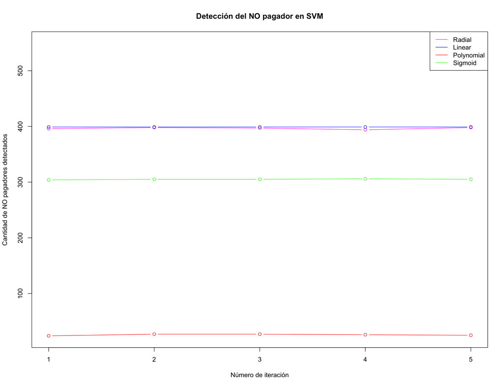

```r
plot(deteccion.no.radial, col = "magenta", type = "b",
     ylim = c(min(deteccion.no.radial,
                  deteccion.no.linear, deteccion.no.polynomial,
                  deteccion.no.sigmoid), max(deteccion.no.radial,
                                             deteccion.no.linear, deteccion.no.polynomial,
                                             deteccion.no.sigmoid) + 150), # Cuidado con el + 150, es para ampliar el eje "y"
     main = "Detección del NO pagador en SVM",
     xlab = "Número de iteración",
     ylab = "Cantidad de NO pagadores detectados")
points(deteccion.no.linear, col = "blue", type = "b")
points(deteccion.no.polynomial, col = "red", type = "b")
points(deteccion.no.sigmoid, col = "green", type = "b")
legend("topright", legend = c("Radial", "Linear", "Polynomial", "Sigmoid"),
       col = c("magenta", "blue", "red", "green"), lty = 1, lwd = 1)
```

### Paquete trainR

**Se cargan las librerías**

```r
library(caret)
library(trainR)
```

```r
numero.filas <- nrow(datos)
cantidad.validacion.cruzada <- 5
cantidad.grupos <- 10

deteccion.no.radial <- rep(0, 5)
deteccion.no.linear <- rep(0, 5)
deteccion.no.polynomial <- rep(0, 5)
deteccion.no.sigmoid <- rep(0, 5)

tiempo.usual <- Sys.time()

for(i in seq_len(cantidad.validacion.cruzada)){
  grupos  <- createFolds(1:numero.filas, cantidad.grupos)  # Crea los 10 grupos
  no.radial <- 0
  no.linear <- 0
  no.polynomial <- 0
  no.sigmoid <- 0

  # Este ciclo es el que hace 'cross-validation' (validación cruzada) con 10
  # grupos (Folds)
  for(k in 1:cantidad.grupos) {
    muestra <- grupos[[k]]  # Por ser una lista requiere de doble paréntesis
    ttesting <- datos[muestra, ]
    taprendizaje <- datos[-muestra, ]

    muestra <- grupos[[k]]  # Por ser una lista requiere de doble paréntesis
    ttesting <- datos[muestra, ]
    taprendizaje <- datos[-muestra, ]
    modelo <- train.svm(BuenPagador ~ ., data = taprendizaje, kernel = "radial")
    prediccion <- predict(modelo, ttesting)
    MC <- confusion.matrix(ttesting, prediccion)
    # Detección de los NO Pagadores
    no.radial <- no.radial + MC["No", "No"]

    modelo <- train.svm(BuenPagador ~ ., data = taprendizaje, kernel = "linear")
    prediccion <- predict(modelo, ttesting)
    MC <- confusion.matrix(ttesting, prediccion)
    # Detección de los NO Pagadores
    no.linear <- no.linear + MC["No", "No"]

    modelo <- train.svm(BuenPagador ~ ., data = taprendizaje, kernel = "polynomial")
    prediccion <- predict(modelo, ttesting)
    MC <- confusion.matrix(ttesting, prediccion)
    # Detección de los NO Pagadores
    no.polynomial <- no.polynomial + MC["No", "No"]

    modelo <- train.svm(BuenPagador ~ ., data = taprendizaje, kernel = "sigmoid")
    prediccion <- predict(modelo, ttesting)
    MC <- confusion.matrix(ttesting, prediccion)
    # Detección de los NO Pagadores
    no.sigmoid <- no.sigmoid + MC["No", "No"]
  }

  deteccion.no.radial[i] <- no.radial
  deteccion.no.linear[i] <- no.linear
  deteccion.no.polynomial[i] <- no.polynomial
  deteccion.no.sigmoid[i] <- no.sigmoid
}

tiempo.usual <- Sys.time() - tiempo.usual
```

```r
tiempo.usual
```

```
Time difference of 4.644459 mins
```

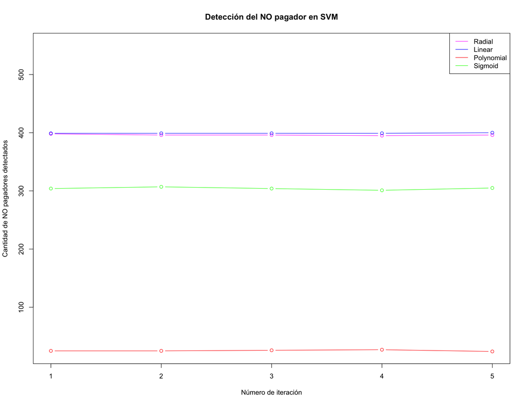

```r
plot(deteccion.no.radial, col = "magenta", type = "b",
     ylim = c(min(deteccion.no.radial,
                  deteccion.no.linear, deteccion.no.polynomial,
                  deteccion.no.sigmoid), max(deteccion.no.radial,
                                             deteccion.no.linear, deteccion.no.polynomial,
                                             deteccion.no.sigmoid) + 150), # Cuidado con el + 150, es para ampliar el eje "y"
     main = "Detección del NO pagador en SVM",
     xlab = "Número de iteración",
     ylab = "Cantidad de NO pagadores detectados")
points(deteccion.no.linear, col = "blue", type = "b")
points(deteccion.no.polynomial, col = "red", type = "b")
points(deteccion.no.sigmoid, col = "green", type = "b")
legend("topright", legend = c("Radial", "Linear", "Polynomial", "Sigmoid"),
       col = c("magenta", "blue", "red", "green"), lty = 1, lwd = 1)
```

**Otra forma de hacerlo es:**

**Se cargan las librerías**

```r
library(caret)
library(trainR)
```

```r
numero.filas <- nrow(datos)
cantidad.validacion.cruzada <- 5
cantidad.grupos <- 10
kernels <- c("radial", "linear", "polynomial", "sigmoid")

resultados <- matrix(0, nrow = cantidad.validacion.cruzada, ncol = 4) # ncol la cantidad de modelos a usar
colnames(resultados) <- kernels # opcional

tiempo.usual <- Sys.time()

for(i in seq_len(cantidad.validacion.cruzada)){
  grupos  <- createFolds(1:numero.filas, cantidad.grupos)  # Crea los 10 grupos

  for(k in 1:cantidad.grupos) {
    muestra <- grupos[[k]]  # Por ser una lista requiere de doble paréntesis
    ttesting <- datos[muestra, ]
    taprendizaje <- datos[-muestra, ]

    for(kernel in kernels) {
      modelo <- train.svm(BuenPagador ~ ., data = taprendizaje, kernel = kernel, probability = TRUE)
      prediccion <- predict(modelo, ttesting)
      MC <- confusion.matrix(ttesting, prediccion)
      resultados[i, kernel] <- resultados[i, kernel] + MC["No","No"] # Detección de los NO Pagadores
    }
  }
}

tiempo.usual <- Sys.time() - tiempo.usual
```

```r
tiempo.usual
```

```
Time difference of 4.687746 mins
```

**El resultado se encuentra en cada columna de `resultados`**

```r
resultados
```

```
     radial linear polynomial sigmoid
[1,]    397    400         27     309
[2,]    397    400         26     304
[3,]    397    400         29     305
[4,]    401    400         30     302
[5,]    394    400         20     303
```

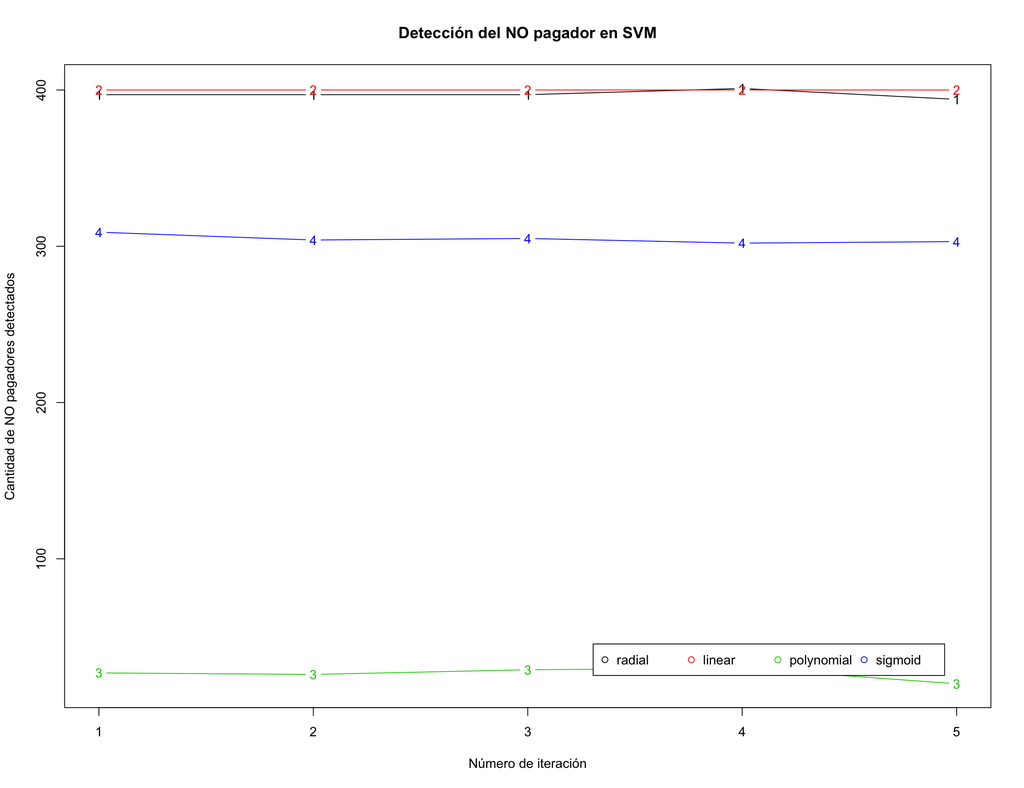

```r
matplot(resultados, type="b",lty = 1, lwd = 1,
        main = "Detección del NO pagador en SVM",
        xlab = "Número de iteración",
        ylab = "Cantidad de NO pagadores detectados")
legend('bottomright', inset=.05, legend = colnames(resultados),
       pch=1, horiz = TRUE, col = 1:4)
```

## Versión Paralela

### Paquete e1071

```r
library(e1071)
library(caret)
library(snow)
```

```r
setwd("~/Desktop/Datos/")
datos <- read.csv("MuestraCredito5000V2.csv", sep = ";", header=T)

# Recodifica las variables como categóricas ordinales
datos$IngresoNeto <- factor(datos$IngresoNeto,ordered = TRUE)
datos$CoefCreditoAvaluo <- factor(datos$CoefCreditoAvaluo,ordered = TRUE)
```

**Proceso Paralelo**

```r
clp <- makeCluster(5, type = "SOCK")
```

**Constructor del cluster**

```r
clusterExport(clp, "datos")

for (indice in 1:5) {
  clusterExport(clp[indice], "indice")
}

tiempo.paralelo <- Sys.time()

resultados <- clusterEvalQ(clp,{
  library(e1071)
  library(caret)
  numero.filas <- nrow(datos)
  cantidad.validacion.cruzada <- 5
  cantidad.grupos <- 10
  kernels <- c("radial", "linear", "polynomial", "sigmoid")

  resultados <- matrix(0, nrow = cantidad.validacion.cruzada, ncol = 4) # ncol la cantidad de modelos a usar
  colnames(resultados) <- kernels # opcional

  grupos  <- createFolds(1:numero.filas, cantidad.grupos)  # Crea los 10 grupos

  for(k in 1:cantidad.grupos) {
    muestra <- grupos[[k]]  # Por ser una lista requiere de doble paréntesis
    ttesting <- datos[muestra, ]
    taprendizaje <- datos[-muestra, ]

    for(kernel in kernels) {
      modelo <- svm(BuenPagador ~ ., data = taprendizaje, kernel = kernel, probability = TRUE)
      prediccion <- predict(modelo, ttesting)
      MC <- table(ttesting[,6], prediccion)
      resultados[indice, kernel] <- resultados[indice, kernel] + MC["No","No"] # Detección de los NO Pagadores
    }
  }
  return(resultados)
})

tiempo.paralelo <- Sys.time() - tiempo.paralelo

resultados <- Reduce("+", resultados)

stopCluster(clp)
```

```r
tiempo.paralelo
```

```
Time difference of 1.499471 mins
```

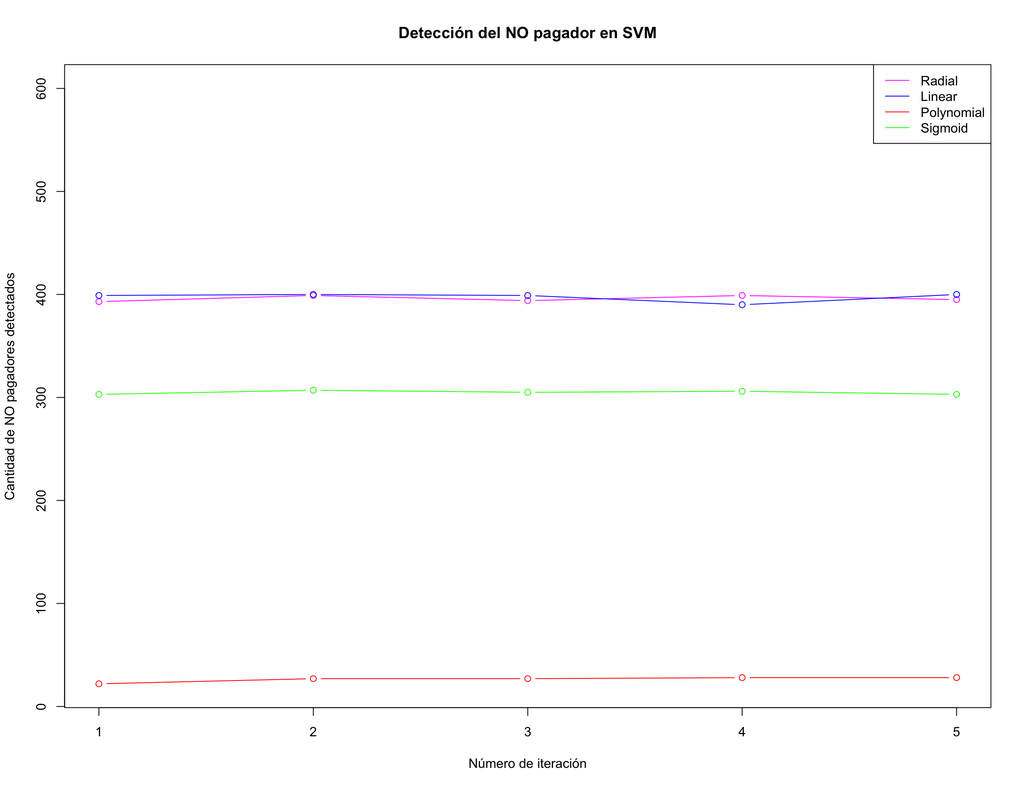

```r
# Proceso Paralelo
suppressWarnings(suppressMessages(library(snow)))
clp <- makeCluster(5, type = "SOCK")
# Constructor del cluster
ignore <- clusterEvalQ(clp, {
      suppressWarnings(suppressMessages(library(e1071)))
      suppressWarnings(suppressMessages(library(formula.tools)))

      ejecutar.prediccion <- function(datos, formula, muestra,metodo, ...) {
        ttesting <- datos[muestra, ]
        taprendizaje <- datos[-muestra, ]
        modelo <- metodo(formula, data = taprendizaje, ...)
        prediccion <- predict(modelo, ttesting, type = "class")
        # Obtiene la variable dependiente de la fórmula. Se ocupa
        # usar el paquete formula.tools
        variable.discriminante <- lhs.vars(formula)
        MC <- table(ttesting[, variable.discriminante], prediccion)
        return(MC)
      }
})

suppressMessages(library(caret))
setwd("~/Desktop/Datos/")
datos <- read.csv("MuestraCredito5000V2.csv",sep = ";",header=T)
# Recodifica las variables como categóricas ordinales
datos$IngresoNeto <- factor(datos$IngresoNeto,ordered = TRUE)
datos$CoefCreditoAvaluo <- factor(datos$CoefCreditoAvaluo,ordered = TRUE)
n <- dim(datos)[1]
algoritmos <- c("radial", "linear", "polynomial", "sigmoid")
deteccion.no.radial <- rep(0, 5)
deteccion.no.linear <- rep(0, 5)
deteccion.no.polynomial <- rep(0, 5)
deteccion.no.sigmoid <- rep(0, 5)
tiempo.paralelo <- Sys.time()
  for (i in 1:5) {
      grupos <- createFolds(1:n, 10)
      no.radial <- 0
      no.linear <- 0
      no.polynomial <- 0
      no.sigmoid <- 0
      for (k in 1:10) {
            muestra <- grupos[[k]]
            ### Inserta estas 2 variables en cada peón
            clusterExport(clp, "datos")
            clusterExport(clp, "muestra")
            resultado <- clusterApply(clp, algoritmos, function(pkernels) {
                  MC <- ejecutar.prediccion(datos, BuenPagador ~ .,muestra, svm, kernel = pkernels)
                  no.val <- MC[1, 1]
                  valores <- list(Tipo <- pkernels, Resultado <- no.val,MC <- MC)
                  valores
            })
            for (j in 1:length(algoritmos)) {
              if (resultado[[j]][[1]] == "radial")
                 no.radial <- no.radial + resultado[[j]][[2]]
              else if (resultado[[j]][[1]] == "linear")
                 no.linear <- no.linear + resultado[[j]][[2]]
              else if (resultado[[j]][[1]] == "polynomial")
                 no.polynomial <- no.polynomial + resultado[[j]][[2]]
              else if (resultado[[j]][[1]] == "sigmoid")
                 no.sigmoid <- no.sigmoid + resultado[[j]][[2]]
            }
      }
      deteccion.no.radial[i] <- no.radial
      deteccion.no.linear[i] <- no.linear
      deteccion.no.polynomial[i] <- no.polynomial
      deteccion.no.sigmoid[i] <- no.sigmoid
  }
tiempo.paralelo <- Sys.time() - tiempo.paralelo
stopCluster(clp)
plot(deteccion.no.radial, col = "magenta", type = "b", ylim =
       c(min(deteccion.no.radial,deteccion.no.linear, deteccion.no.polynomial, deteccion.no.sigmoid),
max(deteccion.no.radial, deteccion.no.linear, deteccion.no.polynomial,
deteccion.no.sigmoid) + 200), main = "Detección del NO pagador en SVM",
xlab = "Número de iteración", ylab = "Cantidad de NO pagadores detectados")
points(deteccion.no.linear, col = "blue", type = "b")
points(deteccion.no.polynomial, col = "red", type = "b")
points(deteccion.no.sigmoid, col = "green", type = "b")
legend("topright", legend = c("Radial", "Linear", "Polynomial",
"Sigmoid"), col = c("magenta", "blue", "red", "green"), lty = 1,lwd = 1)
```

```r
tiempo.paralelo
```

```
Time difference of 32.55619 secs
```